# 8. Exponential Smoothing

Russ Conte

10/30/2021

The simplest of the exponentially smoothing methods is naturally called **simple exponential smoothing (SES)**. This method is suitable for forecasting data with no clear trend or seasonal pattern. For example, the data in Figure 8.1 do not display any clear trending behaviour or any seasonality. (There is a decline in the last few years, which might suggest a trend. We will consider whether a trended method would be better for this series later in this chapter.) We have already considered the naïve and the average as possible methods for forecasting such data (Section 5.2).

```r
library(fpp3)
library(tidyverse)
```

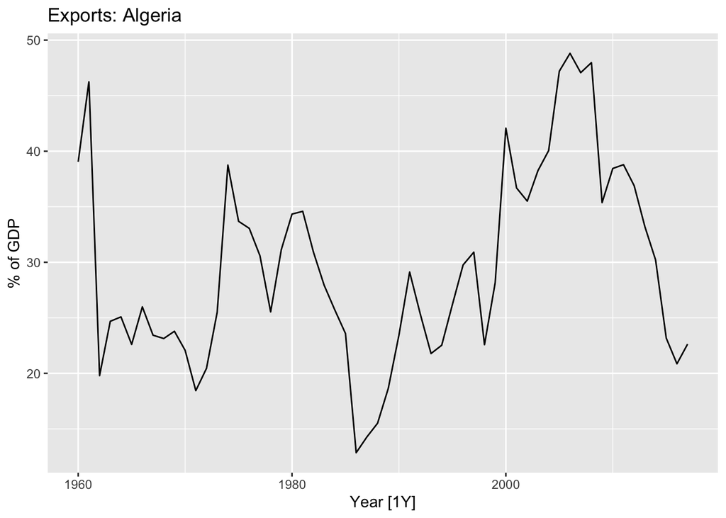

```r
algeria_economy <- global_economy %>%
  filter(Country == "Algeria")
algeria_economy %>%
  autoplot(Exports) +
  labs(y = "% of GDP", title = "Exports: Algeria")
```

Using the naïve method, all forecasts for the future are equal to the last observed value of the series,

for $h = 1, 2, ....$ Hence, the average method assumes that all observations are of equal importance, and gives them equal weights when generating forecasts.

We often want something between these two extremes. For example, it may be sensible to attach larger weights to more recent observations than to observations from the distant past. This is exactly the concept behind simple exponential smoothing. Forecasts are calculated using weighted averages, where the weights decrease exponentially as observations come from further in the past — the smallest weights are associated with the oldest observations.

$\hat{y}_{T+1|T} = \alpha y_T + \alpha(1 - \alpha)y_{T - 1} + \alpha(1 - \alpha)^2y_{T-2} + ...,$

where $0 \le \alpha \le 1$ is the smoothing parameter.The one-step-ahead forecast for time $T + 1$ is a weighted average of all of the observations in the series $y_1, ... y_T$ . The rate at which the weights decrease is controlled by the parameter $\alpha$.

The table below shows the weights attached to observations for four different values of $$ when forecasting using simple exponential smoothing. Note that the sum of the weights even for a small value of $\alpha$ will be approximately one for any reasonable sample size.

|  | $\alpha$=0.2 | $\alpha$=0.4 | $\alpha$=0.6 | $\alpha$ = 0.8 |  |
| --- | --- | --- | --- | --- | --- |
| $y_t$ | 0.2000 | 0.4000 | 0.600 | 0.800 |  |
| $y_{T-1}$ | 0.1600 | 0.2400 | 0.2400 | 0.1600 |  |
| $y_{T-2}$ | 0.1280 | 0.1440 | 0.0960 | 0.0320 |  |
| $y_{T-3}$ | 0.1024 | 0.0864 | 0.0384 | 0.0064 |  |
| $y_{T-4}$ | 0.0819 | 0.0518 | 0.0154 | 0.0013 |  |
| $y_{T-5}$ | 0.0655 | 0.0311 | 0.0061 | 0.0003 |  |

For any $\alpha$ between 0 and 1, the weights attached to the observations decrease exponentially as we go back in time, hence the name “exponential smoothing.” If $\alpha$ is small (i.e., close to 0), more weight is given to observations from the more distant past. If $\alpha$ is large (i.e., close to 1), more weight is given to the more recent observations. For the extreme case where $\alpha = 1, \hat{y}_{T+1|T} = y_T$, and the forecasts are equal to the naïve forecasts.

## Weighted average form

The forecast at time $T + 1$ is equal to a weighted average between themost recen tobservation, $t_T$ and the previous forecast $\hat{y}_{T|T-1}$:

$\hat{y}_{T+1} = \alpha y_T + (1 - \alpha) \hat{y}_{T|T-1}$

where $\alpha$ is the smoothing parameter. Similary, we can write the fitted values as:

$\hat{y}_{t+1|t} = \alpha y_t + (1 - \alpha) \hat{y}_{t|{t-1}}$

for $t = 1, ...T$. (Recall that fitted values are simply one step forecasts of the training data.)

The process has to start somewhere, so we let the first fitted value at time 1 be denoted by $\ell_0$, which we will have to estimate. Then:

$\hat{y}_{2|1} = \alpha y_1 + (1 - \alpha) \ell_0$  
$\hat{y}_{3|2} = \alpha y_2 + (1 - \alpha) \hat{y}_{2|1}$  
$\hat{y}_{4|3} = \alpha y_2 + (1 - \alpha) \hat{y}_{3|2}$  
. . . $\hat{y}_{T|{T-1}} = \alpha y_{T-1} + (1 - \alpha) \hat{y}_{T-1|T-2}$  
$\hat{y}_{T+1|T} = \alpha y_{T} + (1 - \alpha) \hat{y}_{T|T-1}$  
.  
.  
.  
$\hat{y}_{T+1|t} = \sum_{j=0}^{T-1} \alpha(1 - \alpha)^j y_{T-j} + (1 - \alpha)^T \ell_0$

## Component form

An alternative representation is the component form. For simple exponential smoothing, the only component included is the level $\ell_t$,(Other methods which are considered later in this chapter may also include a trend $b_t$ and a seasonal component $s_t$.) Component form representations of exponential smoothing methods comprise a forecast equation and a smoothing equation for each of the components included in the method. The component form of simple exponential smoothing is given by:

$\text{Forecast equation } \hat{y}_{t+h|t} = \ell_t$  
$\text{Smoothing equation } \ell_t = \alpha y_t + (1 - \alpha) \ell_{t_1}$

where $\ell_t$ is the level (or the smoothed value) of the series at time $t$ Setting $h = 1$ gives the fitted values, while setting $t = T$ gives the true forecast beyond the training data.

The forecast equation shows that the forecast value at time $t + 1$ is the estimated level at time $t$. The smoothing equation for the level (usually referred to as the level equation) gives the estimated level of the series at each period $t$.

If we replace $\ell_t$ with $\hat{y}_{t+1|t}$ and $\ell_{t-1}$ with $\hat{y}_{t|t-1}$ in the smoothing equation, we will recover the weighted average form of simple exponential smoothing.

The component form of simple exponential smoothing is not particularly useful on its own, but it will be the easiest form to use when we start adding other components.

## Optimisation

The application of every exponential smoothing method requires the smoothing parameters and the initial values to be chosen. In particular, for simple exponential smoothing, we need to select the values of $\alpha$ and $\ell_0$. All forecasts can be computed from the data once we know those values. For the methods that follow there is usually more than one smoothing parameter and more than one initial component to be chosen.

In some cases, the smoothing parameters may be chosen in a subjective manner — the forecaster specifies the value of the smoothing parameters based on previous experience. However, a more reliable and objective way to obtain values for the unknown parameters is to estimate them from the observed data.

In Section 7.2, we estimated the coefficients of a regression model by minimising the sum of the squared residuals (usually known as SSE or “sum of squared errors”). Similarly, the unknown parameters and the initial values for any exponential smoothing method can be estimated by minimising the SSE. The residuals are specified as $e_t = y_t - \hat{y}_{t|t-1}$ for $t = 1,...T$. Hence, we find the values of the unknown parameters and the initial values that minimise

$SSE = \sum_{t=1}^T (y_t - \hat{y}_{t|{t-1}})^2 = \sum_{t = 1}^T e_t^2$

Unlike the regression case (where we have formulas which return the values of the regression coefficients that minimise the SSE), this involves a non-linear minimisation problem, and we need to use an optimisation tool to solve it.

## Algerian exports

In this example, simple exponential smoothing is applied to forecast exports of goods and services from Algeria.

```r
# Estimate parameters
fit <- algeria_economy %>%
  model(ETS(Exports ~ error("A") + trend("N") + season("N")))

forecast1 <- fit %>%
  forecast(h = 5)

forecast1
```

```
## # A fable: 5 x 5 [1Y]
## # Key:     Country, .model [1]
##   Country .model                                           Year    Exports .mean
##   <fct>   <chr>                                           <dbl>     <dist> <dbl>
## 1 Algeria "ETS(Exports ~ error(\"A\") + trend(\"N\") + s…  2018  N(22, 36)  22.4
## 2 Algeria "ETS(Exports ~ error(\"A\") + trend(\"N\") + s…  2019  N(22, 61)  22.4
## 3 Algeria "ETS(Exports ~ error(\"A\") + trend(\"N\") + s…  2020  N(22, 86)  22.4
## 4 Algeria "ETS(Exports ~ error(\"A\") + trend(\"N\") + s…  2021 N(22, 111)  22.4
## 5 Algeria "ETS(Exports ~ error(\"A\") + trend(\"N\") + s…  2022 N(22, 136)  22.4
```

```r
report(fit)
```

```
## Series: Exports
## Model: ETS(A,N,N)
##   Smoothing parameters:
##     alpha = 0.8399875
##
##   Initial states:
##    l[0]
##  39.539
##
##   sigma^2:  35.6301
##
##      AIC     AICc      BIC
## 446.7154 447.1599 452.8968
```

This gives parameter estimates $\hat{\alpha} = 0.8399875$ and $\hat{\ell_0} = 39.5$ obtained by minimising SSE over periods $t = 1, 2, ... 58$, subject to the restriction that $0 \le \alpha \le 1$

In Table 8.1 we demonstrate the calculation using these parameters. The second last column shows the estimated level for times $t = 0$ to $t = 58$; the last few rows of the last column show the forecasts for $h = 1\text{ to }5$-steps ahead.

Table 8.1: Forecasting goods and services exports from Algeria using simple exponential smoothing.

| **Year** | Time | Observation | Level | Forecast |
| --- | --- | --- | --- | --- |
|  | $t$ | $y_t$ | $\ell_t$ | $\hat{y}_{t\|{t-1}}$ |
| 1959 | 0 |  | 39.54 |  |
| 1960 | 1 | 39.04 | 39.12 | 39.54 |
| 1961 | 2 | 46.24 | 45.10 39.12 |  |
| 1962 | 3 | 19.79 | 23.84 | 45.10 |
| 1963 | 4 | 24.68 | 24.55 | 23.84 |
| 1964 | 5 | 25.08 | 25.00 | 24.55 |
| 2014 | 55 | 30.22 | 30.80 | 33.85 |
| 2015 | 56 | 23.17 | 24.39 | 30.80 |
| 2016 | 57 | 20.86 | 21.43 | 24.39 |
| 2017 | 58 | 22.64 | 22.44 | 21.43 |
|  | $h$ |  |  | $\hat{y}_{T+h\|T}$ |
| 2018 | 1 |  |  | 22.44 |
| 2019 | 2 |  |  | 22.44 |
| 2020 | 3 |  |  | 22.44 |
| 2021 | 4 |  |  | 22.44 |

The black line in Figure 8.2 sows the data, which has a changing value over time.

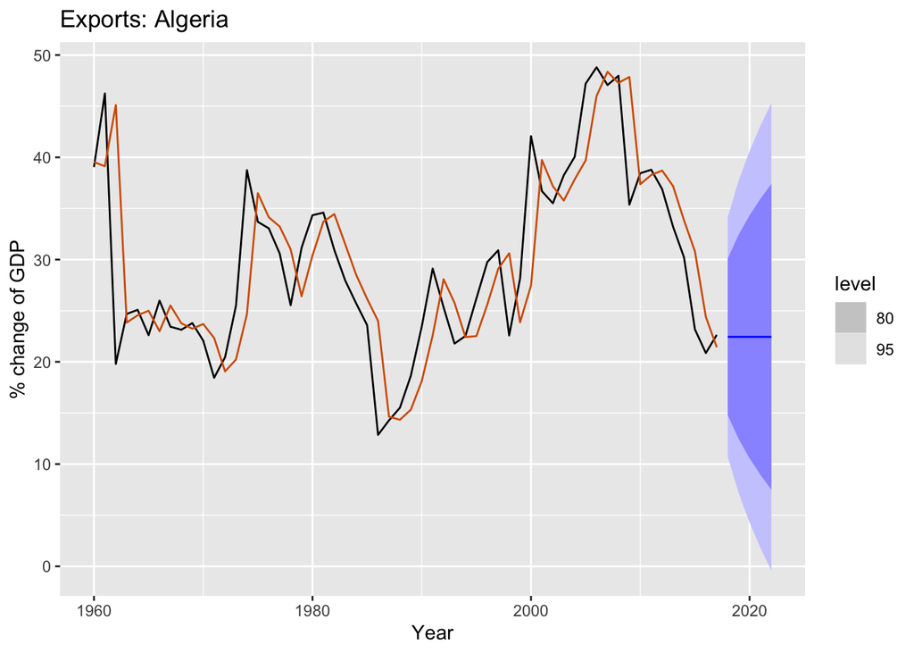

```r
forecast1 %>%
  autoplot(algeria_economy)+
  geom_line(aes(y = .fitted), col = "#D55E00", data = augment(fit)) +
  labs(y = "% change of GDP", title = "Exports: Algeria") +
  guides(colour = "none")
```

The forecasts for the period 2018–2022 are plotted in Figure 8.2. Also plotted are one-step-ahead fitted values alongside the data over the period 1960–2017. The large value of $\alpha$in this example is reflected in the large adjustment that takes place in the estimated level $\ell_t$at each time. A smaller value of $\alpha$would lead to smaller changes over time, and so the series of fitted values would be smoother.

The prediction intervals shown here are calculated using the methods described in Section 8.7. The prediction intervals show that there is considerable uncertainty in the future exports over the five-year forecast period. So interpreting the point forecasts without accounting for the large uncertainty can be very misleading.

## 8.2 Methods with trend

Holt (1957) extended simple exponential smoothing to allow the forecasting of data with a trend. This method involves a forecast equation and two smoothing equations (one for the level and one for the trend):

$\text{Forecast equation } \hat{y}_{t+h|t} = \ell_t + h b_t$  
$\text{Level equation } \ell_t = \alpha y_t + (1 - \alpha)(\ell{t-1} + b_{t-1})$  
$\text{Trend equation } b_t = \beta^* (\ell_t - \ell_{t-1}) + (1 - \beta^*)b_{t-1}$

where $\ell_t$ denotes an estiamte of the level of the series at time $t, b_t$ denotes an estimate of the trend (slope) of the series at time $t, \alpha$ is the smoothing parameter for the level $0 \le \alpha \le 1$ and $\beta^*$ is the smoothing paramter for the trend, $0 \le \beta^* \le 1$.

As with simple expoential smoothing, the level equation here shows that $\ell_t$ is a weighted average of ovservation $y_t$ and the one-step-ahead trainig forecast for time $t$, here given by $\ell_{t-1} + b_{t-1}$. The trend equation shows that $b_t$ is a weighted average of the estimated trend at time $t$ based on $\ell_t - \ell_{t-1}$ and $b_{t-1}$, the previous estimate of the trend.

The forecast function is no longer flat but trending. The $h$-step-ahead forecast is equal to the last estimated level plus $h$ times the last estimated trend value. Hence the forecasts are a linear function of $h$.

## Example: Australian population

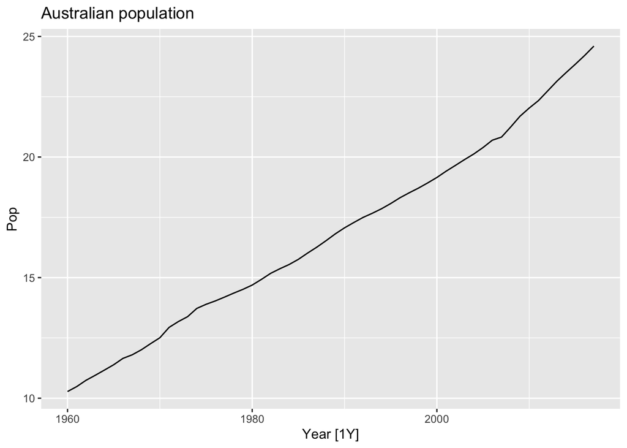

```r
aus_economy <- global_economy %>%
  filter(Code == "AUS") %>%
  mutate(Pop = Population / 1e6)
autoplot(aus_economy, Pop) +
  labs("y = Millions", title = "Australian population")
```

Figure 8.3 shows Australia’s annual population from 1960 to 2017. We will apply Holt’s method to this series. The smoothing parameters, $\alpha$ and $\beta^*$, and the initial values $\ell_0$ and $b_0$are estimated by minimising the SSE for the one-step training errors as in Section 8.1.

```r
fit <- aus_economy %>%
  model(
    AAN = ETS(Pop ~ error("A") + trend("A") + season("N"))
    )
forecast2 <- fit %>% forecast(h = 10)
forecast2
```

```
## # A fable: 10 x 5 [1Y]
## # Key:     Country, .model [1]
##    Country   .model  Year           Pop .mean
##    <fct>     <chr>  <dbl>        <dist> <dbl>
##  1 Australia AAN     2018 N(25, 0.0041)  25.0
##  2 Australia AAN     2019  N(25, 0.011)  25.3
##  3 Australia AAN     2020  N(26, 0.023)  25.7
##  4 Australia AAN     2021  N(26, 0.039)  26.1
##  5 Australia AAN     2022  N(26, 0.061)  26.4
##  6 Australia AAN     2023   N(27, 0.09)  26.8
##  7 Australia AAN     2024   N(27, 0.13)  27.2
##  8 Australia AAN     2025   N(28, 0.17)  27.6
##  9 Australia AAN     2026   N(28, 0.22)  27.9
## 10 Australia AAN     2027   N(28, 0.29)  28.3
```

Table 8.2 Forecasting Australian annual population using Holt’s linear trend method

| Year | Time | Observation | Level | Slope | Forecast | Difference |
| --- | --- | --- | --- | --- | --- | --- |
|  | $t$ | $y_t$ | $\ell_t$ |  | $\hat{y}_{t+1\|t}$ |  |
| 1959 | 0 |  | 10.05 | 0.22 |  |  |
| 1960 | 1 | 10.28 | 10.28 | 0.22 | 10.20 | 0 |
| 1961 | 2 | 10.28 | 10.48 | 0.22 | 10.50 | 0.02 |
| 1962 | 3 | 10.74 | 10.74 | 0.23 | 10.70 | -0.04 |
| 1963 | 4 | 10.95 | 10.95 | 0.22 | 10.97 | +0.02 |
| 1964 | 5 | 11.17 | 11.17 | 0.22 | 11.17 | 0 |
| 1965 | 6 | 11.39 | 11.39 | 0.22 | 11.39 | 0 |
| 1966 | 7 | 11.65 | 11.65 | 0.23 | 11.61 | +.04 |
| 2014 | 55 | 23.50 | 23.50 | 0.37 | 23.52 | -0.02 |
| 2015 | 56 | 23.85 | 23.85 | 0.36 | 23.87 | 0.02 |
| 2016 | 57 | 24.21 | 24.21 | 0.36 | 24.21 | 0 |
| 2017 | 58 | 24.60 | 24.60 | 0.37 | 24.57 | -0.03 |
|  | $h$ |  |  |  | $\hat{y}_{T=h\|T}$ |  |
| 2018 | 1 |  |  |  | 24.97 |  |
| 2019 | 2 |  |  |  | 25.34 |  |
| 2020 | 3 |  |  |  | 25.71 |  |
| 2021 | 4 |  |  |  | 26.07 |  |
| 2022 | 5 |  |  |  | 26.44 |  |
| 2023 | 6 |  |  |  | 26.81 |  |
| 2024 | 7 |  |  |  | 27.18 |  |
| 2025 | 8 |  |  |  | 27.55 |  |
| 2026 | 9 |  |  |  | 27.92 |  |
| 2-27 | 10 |  |  |  | 28.29 |  |

The forecasts generated by Holt’s linear method display a constant trend (increasing or decreasing) indefinitely into the future. Empirical evidence indicates that these methods tend to over-forecast, especially for longer forecast horizons. Motivated by this observation, Gardner & McKenzie (1985) introduced a parameter that “dampens” the trend to a flat line some time in the future. Methods that include a damped trend have proven to be very successful, and are arguably the most popular individual methods when forecasts are required automatically for many series.

In conjunction with the smoothing parameters $\alpha$ and $\beta^*$ (with values between 0 and 1 as in Hold’s method), this method also includes a dampeng paramter $0 \le \phi \le 1$  
$\hat{y}_{t+h|t} = \ell_t + (\phi + \phi^2 + ... + \phi^h)b_t$  
$\ell_t = \alpha y_t + (1 - \alpha)(\ell_{t - 1} + \phi b_{t - 1})$  
$b_t = \beta^*(\ell_t - \ell_{t - 1} + (1 - \beta^*) \phi b_{t-1})$

If $\phi = 1$, the method is idential to Holt’s method. For values between 0 and 1, $\phi$ dampens the trend so that it approaches a constant some time in the future. In fact, the forecasts converge to: $\ell_t + \phi_{b_T}/(1 - \phi)$ as $h\rightarrow \infty$ for any value $0 \le \phi \le 1$. This means that short term forecasts are trended, while long term forecasts are constant.

In practice, $\phi$ is rarely less than 0.8 as the damping has a very strong effect for smaller values. Values of $\phi$ close to 1 will mean that a damped model is not able to be distinguished from a non-damped model. For these reasons, we usually restrict $\phi$ to a minimum of 0.8 and a maximum of 0.98.

## Example: Australian Population (continued)

Figure 8.4 shows the forecasts for years 2018–2032 generated from Holt’s linear trend method and the damped trend method.

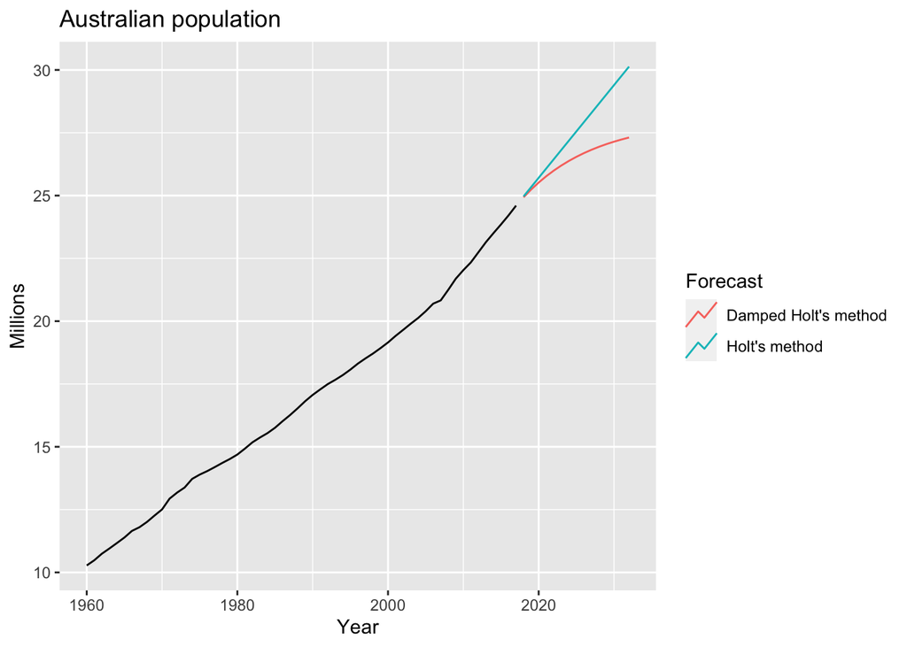

```r
aus_economy %>%
  model(
    `Holt's method` = ETS(Pop ~ error("A") +
                       trend("A") + season("N")),
    `Damped Holt's method` = ETS(Pop ~ error("A") +
                       trend("Ad", phi = 0.9) + season("N"))
  ) %>%
  forecast(h = 15) %>%
  autoplot(aus_economy, level = NULL) +
  labs(title = "Australian population",
       y = "Millions") +
  guides(colour = guide_legend(title = "Forecast"))
```

## Example: Internet usage

In this example, we compare the forecasting performance of the three exponential smoothing methods that we have considered so far in forecasting the number of users connected to the internet via a server. The data is observed over 100 minutes and is shown in Figure 8.5.

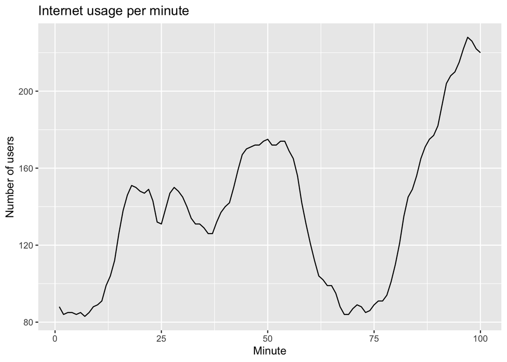

```r
www_usage <- as_tsibble(WWWusage)
www_usage %>% autoplot(value) +
  labs(x = "Minute", y = "Number of users",
       title = "Internet usage per minute")
```

We will use time series cross-validation to compare the one-step forecast accuracy of the three methods.

```r
www_usage %>%
  stretch_tsibble(.init = 10) %>%
  model(
    SES = ETS(value ~ error("A") + trend("N") + season("N")),
    Holt = ETS(value ~ error("A") + trend("A") + season("N")),
    Damped = ETS(value ~ error("A") + trend("Ad") + season("N"))
    ) %>%
  forecast(h = 1) %>%
  accuracy(www_usage)
```

```
## # A tibble: 3 × 10
##   .model .type     ME  RMSE   MAE   MPE  MAPE  MASE RMSSE  ACF1
##   <chr>  <chr>  <dbl> <dbl> <dbl> <dbl> <dbl> <dbl> <dbl> <dbl>
## 1 Damped Test  0.288   3.69  3.00 0.347  2.26 0.663 0.636 0.336
## 2 Holt   Test  0.0610  3.87  3.17 0.244  2.38 0.701 0.668 0.296
## 3 SES    Test  1.46    6.05  4.81 0.904  3.55 1.06  1.04  0.803
```

Damped Holt’s method is best whether you compare MAE or RMSE values. So we will proceed with using the damped Holt’s method and apply it to the whole data set to get forecasts for future minutes.

```r
fit <- www_usage %>%
  model(
    Damped = ETS(value ~ error("A") + trend("Ad") + season("N"))
    )

#Estimated parameters

tidy(fit)
```

```
## # A tibble: 5 × 3
##   .model term  estimate
##   <chr>  <chr>    <dbl>
## 1 Damped alpha   1.00
## 2 Damped beta    0.997
## 3 Damped phi     0.815
## 4 Damped l[0]   90.4
## 5 Damped b[0]   -0.0173
```

The smoothing parameter for the slope is estimated to be almost one, indicating that the trend changes to mostly reflect the slope between the last two minutes of internet usage. The value of $\alpha$ is very close to one, showing that the level reacts strongly to each new observation.

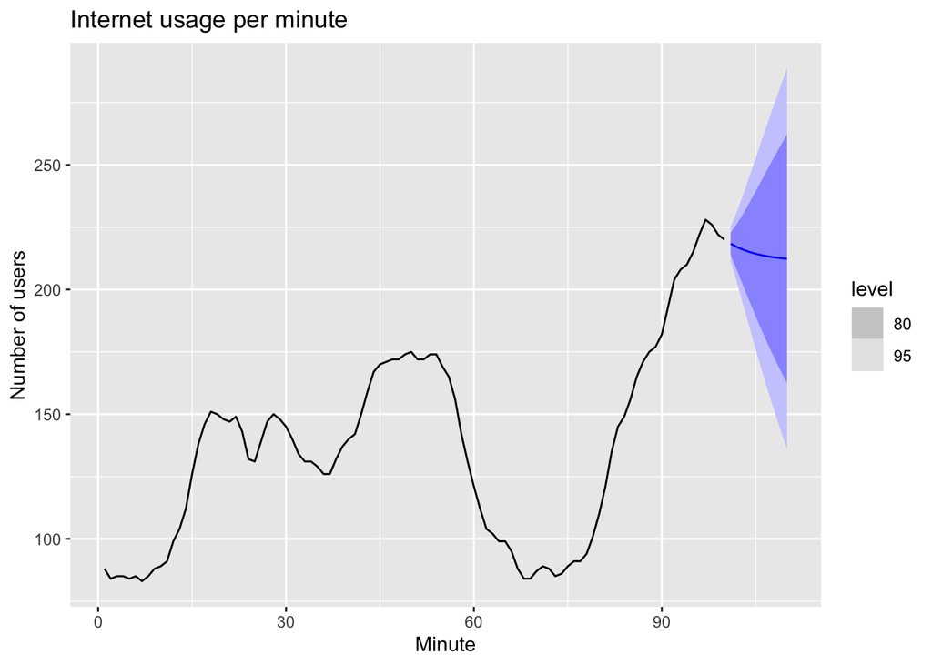

```r
fit %>%
  forecast(h = 10) %>%
  autoplot(www_usage) +
  labs(x = "Minute", y = "Number of users", title = "Internet usage per minute")
```

## Methods with seasonality

Holt (1957) and Winters (1960) extended Holt’s method to capture seasonality. The Holt-Winters seasonal method comprises the forecast equation and three smoothing equations — one for the level$\ell_t$one for the trend $b_t$, and one for the seasonal component $s_t$, with corresponding smoothing parameters $\alpha, \beta^* \text{ and } \gamma$. We use $m$to denote the period of the seasonality, i.e., the number of seasons in a year. For example, for quarterly data $m = 4$, and for monthly data $m = 12$.

There are two variations to this method that differ in the nature of the seasonal component. The additive method is preferred when the seasonal variations are roughly constant through the series, while the multiplicative method is preferred when the seasonal variations are changing proportional to the level of the series. With the additive method, the seasonal component is expressed in absolute terms in the scale of the observed series, and in the level equation the series is seasonally adjusted by subtracting the seasonal component. Within each year, the seasonal component will add up to approximately zero. With the multiplicative method, the seasonal component is expressed in relative terms (percentages), and the series is seasonally adjusted by dividing through by the seasonal component. Within each year, the seasonal component will sum up to approximately $m$.

## Holt-Winter’s Additive Method

The component form of the additive method is:

$\hat{y}_{t+h|t} = \ell_t + hb_t + s_{t+h+m(k+1)}$  
$\ell_t = \alpha(y_t - s_{t-m}) + (1 - \alpha)(\ell_{t-1} + b_{t-1})$  
$b_t =\beta^*(\ell_t - \ell_{t-1}) + (1 - \beta^*)b_{t-1}$  
$s_t = \gamma(y_t - \ell_{t-1} - b_{t-1}) + (1 - \gamma)s_{t-m}$

where $k$is the integer part of $(h-1)/m$, which ensures that the estimates of the seasonal indices used for forecasting come from the final year of the sample. The level equation shows a weighted average between the seasonally adjusted observation $(y_t - s_{t-m})$ and the non-seasonal forecast $(\ell_{t-1} + b_{t-1})$ for time $t$. The trend equation is identical to Holt’s linear method. The seasonal equation shows a weighted average between the current seasonal index, $(y_t - \ell_{t-1} - b_{t-1})$ , and the seasonal index of the same season last year (i.e., $m$time periods ago).

The equation for the seasonla component is often expressed as:

$s_t = \gamma^*(y_t - \ell_t) + (1 - \gamma^*) s_{t - m}$

If we substitute $\ell_t$ from the smoothing equation for the level of the component form above, we get:

$s_t = \gamma^*(1 - \alpha)(y_t - \ell_{t-1} - b_{t-1}) + [1 - \gamma^*(1 - \alpha)]s_{t-m}$

which is identical to the smoothing equation for the seasonal component we specify here, with $\gamma = \gamma^*(1 - \alpha)$. The usual parameter restriction is $0 \le \gamma^* \le1$ which translates to $0 \le \gamma \le 1 - \alpha$

## Holt-Winter’s Multiplicative method

The component form of the multiplicative method is:

$\hat{y}_{t+h|t} = (\ell_t + hb_t)s_{t+h-m(k+1)}$  
$\ell_t = \alpha \frac{y_t}{s_{t-m}} + (1 - \alpha)(\ell_{t - 1} + b_{t-1})$  
$b_t = \beta^*(\ell_t - \ell_{t-1} + (1 - \beta^*))b_{t-1}$  
$s_t = \gamma\frac{y_t}{(\ell_t + b_{t-1})}+ (1 - \gamma)s_{t - m}$

## Example: Domestic overnight trips in Australia

We apply Holt-Winters’ method with both additive and multiplicative seasonality14 to forecast quarterly visitor nights in Australia spent by domestic tourists. Figure 8.7 shows the data from 1998–2017, and the forecasts for 2018–2020. The data show an obvious seasonal pattern, with peaks observed in the March quarter of each year, corresponding to the Australian summer.

```r
aus_holidays <- tourism %>%
  filter(Purpose == "Holiday") %>%
  summarise(Trips = sum(Trips)/1e3)

fit <- aus_holidays %>%
  model(
    additive = ETS(Trips ~ error("A") + trend("A") + season("A")),
    multiplicative = ETS(Trips ~ error("M") + trend("A") + season("M"))
  )

fit1<- aus_holidays %>%
  model(
    additive = ETS(Trips ~ error("A") + trend("A") + season("A")))

fit2<- aus_holidays %>%
  model(
    multiplicative = ETS(Trips ~ error("M") + trend("A") + season("M")))

report(fit1)
```

```
## Series: Trips
## Model: ETS(A,A,A)
##   Smoothing parameters:
##     alpha = 0.2620382
##     beta  = 0.04314266
##     gamma = 0.0001000312
##
##   Initial states:
##      l[0]       b[0]      s[0]      s[-1]      s[-2]    s[-3]
##  9.791341 0.02106875 -0.534408 -0.6697662 -0.2937802 1.497954
##
##   sigma^2:  0.1931
##
##      AIC     AICc      BIC
## 228.5676 231.1390 250.0058
```

```r
report(fit2)
```

```
## Series: Trips
## Model: ETS(M,A,M)
##   Smoothing parameters:
##     alpha = 0.2236926
##     beta  = 0.03042124
##     gamma = 0.0001000009
##
##   Initial states:
##      l[0]        b[0]      s[0]     s[-1]     s[-2]    s[-3]
##  10.01351 -0.01141645 0.9430572 0.9270043 0.9692079 1.160731
##
##   sigma^2:  0.0021
##
##      AIC     AICc      BIC
## 226.7196 229.2910 248.1578
```

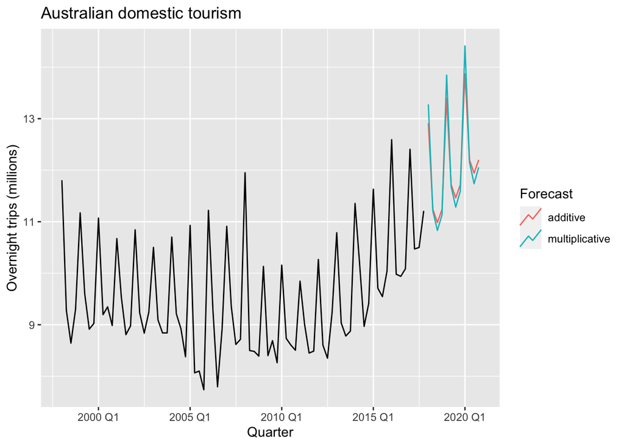

```r
forecast2 <- fit %>% forecast(h = "3 years")
forecast2 %>% autoplot(aus_holidays, level = NULL) +
  labs(title = "Australian domestic tourism",
       y = "Overnight trips (millions)") +
  guides(colour = guide_legend(title = "Forecast"))
```

```r
forecast2
```

```
## # A fable: 24 x 4 [1Q]
## # Key:     .model [2]
##    .model   Quarter       Trips .mean
##    <chr>      <qtr>      <dist> <dbl>
##  1 additive 2018 Q1 N(13, 0.19)  12.9
##  2 additive 2018 Q2 N(11, 0.21)  11.2
##  3 additive 2018 Q3 N(11, 0.23)  11.0
##  4 additive 2018 Q4 N(11, 0.26)  11.2
##  5 additive 2019 Q1  N(13, 0.3)  13.4
##  6 additive 2019 Q2 N(12, 0.34)  11.7
##  7 additive 2019 Q3  N(11, 0.4)  11.5
##  8 additive 2019 Q4 N(12, 0.46)  11.7
##  9 additive 2020 Q1 N(14, 0.53)  13.9
## 10 additive 2020 Q2 N(12, 0.61)  12.2
## # … with 14 more rows
```

Table 8.3: Applying Holt-Winters’ method with additive seasonality for forecasting domestic tourism in Australia. Notice that the additive seasonal component sums to approximately zero. The smoothing parameters and initial estimates for the components are $\alpha = 0.260, \beta^* = 0.1646, \gamma = 0.001$ and RMSE = 0.4169 (note that I cannot currently reproduce these results with this data and method of analysis)

| Quarter | time | Observation | Level | Slope | Season | Forecast |
| --- | --- | --- | --- | --- | --- | --- |
|  | $t$ | $y_t$ | $\ell_t$ | $b_t$ | $s_t$ | $\hat{y}_{t+1\|t}$ |
| 1997 Q1 | 0 |  |  |  | 1.5 |  |
| 1997 Q2 | 1 |  |  |  | -0.3 |  |
| 1997 Q3 | 2 |  |  |  | -0.7 |  |
| 1997 Q4 | 3 |  | 9.8 | 0.0 | -0.5 |  |
| 1998 Q1 | 4 | 11.8 | 9.9 | 0.0 | 1.5 | 11.3 |
| 1998 Q2 | 5 | 9.3 | 9.9 | 0.0 | -0.3 | 9.7 |
| • • • | • • • | • • • | • • • | • • • | • • • | • • • |
| 2017 Q1 | 80 | 12.4 | 10.9 | 0.1 | 1.5 | 12.3 |
| 2017 Q2 | 81 | 10.5 | 10.9 | 0.1 | -0.3 | 10.7 |
| 2017 Q3 | 82 | 10.5 | 11.0 | 0.1 | -0.7 | 10.3 |
| 2017 Q4 | 83 | 11.2 | 11.3 | 0.1 | -0.5 | 10.6 |
| $h$ |  |  |  |  |  | $\hat{y}_{T+h\|T}$ |
| 2018 Q1 | 1 |  |  |  |  | 12.9 |
| 2018 Q2 | 2 |  |  |  |  | 11.2 |
| 2018 Q3 | 3 |  |  |  |  | 11.0 |
| 2018 Q4 | 4 |  |  |  |  | 11.2 |
| 2019 Q1 | 5 |  |  |  |  | 13.4 |
| 2019 Q2 | 6 |  |  |  |  | 11.7 |
| 2019 Q3 | 7 |  |  |  |  | 11.5 |
| 2019 Q4 | 8 |  |  |  |  | 11.7 |
| 2020 Q1 | 9 |  |  |  |  | 13.9 |
| 2020 Q2 | 10 |  |  |  |  | 12.2 |
| 2020 Q3 | 11 |  |  |  |  | 11.9 |
| 2020 Q4 | 12 |  |  |  |  | 12.2 |

Table 8.4: Applying Holt-Winters’ method with multiplicative seasonality for forecasting domestic tourism in Australia. Notice that the multiplicative seasonal component sums to approximately $m = 4$. The smoothing parameters and initial estimates for the components are $\alpha = 0.2337, \beta^* = 0.1360, \gamma = 0.0001$ and RMSE = 0.4112

[output not shown]

The applications of both methods (with additive and multiplicative seasonality) are presented in Tables 8.3 and 8.4 respectively. Because both methods have exactly the same number of parameters to estimate, we can compare the training RMSE from both models. In this case, the method with multiplicative seasonality fits the data slightly better.

The estimated states for both models are plotted in Figure 8.8. The small value of $\gamma$ for the multiplicative model means that the seasonal component hardly changes over time. The small value of $\beta$ means the slope component hardly changes over time (compare the vertical scales of the slope and level components).

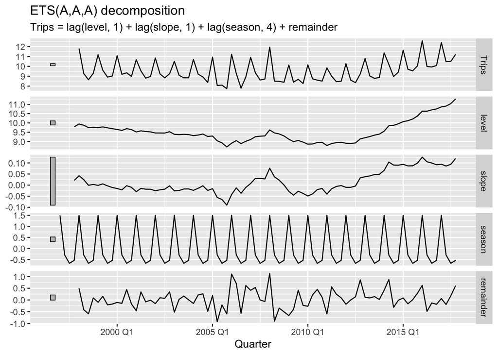

```r
components(fit1) %>%
  autoplot()
```

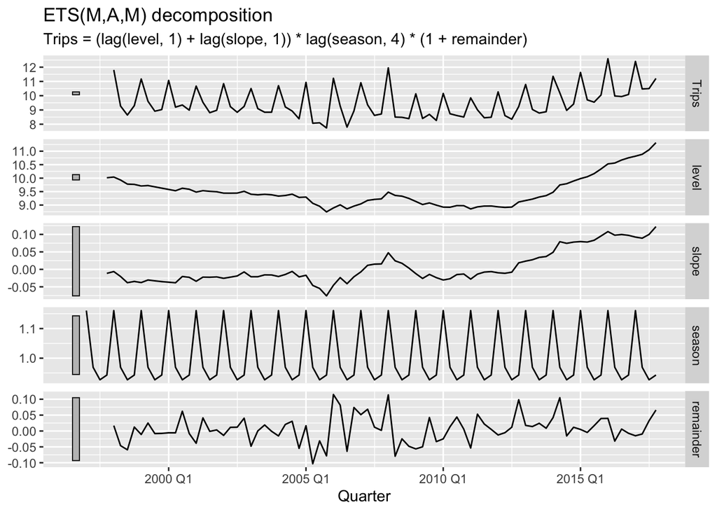

```r
components(fit2) %>%
  autoplot()
```

## Holt-Winters Damped Method

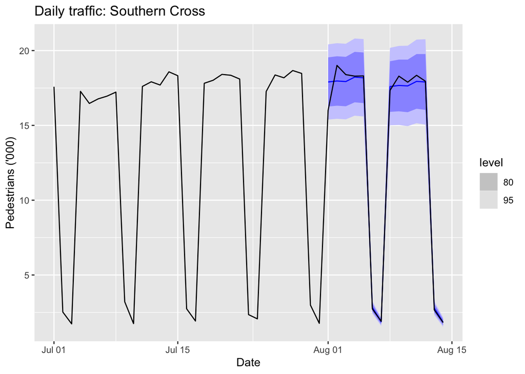

```r
sth_cross_ped <- pedestrian %>%
  filter(Date >= "2016-07-01",
         Sensor == "Southern Cross Station") %>%
  index_by(Date) %>%
  summarise(Count = sum(Count)/1000)

sth_cross_ped %>%
  filter(Date <= "2016-07-31") %>%
  model(
    hw = ETS(Count ~ error("M") + trend("Ad") + season("M"))
    ) %>%
  forecast(h = "2 weeks") %>%
  autoplot(sth_cross_ped %>% filter(Date <= "2016-08-14")) +
  labs(title = "Daily traffic: Southern Cross", y = "Pedestrians ('000)")
```

Clearly the model has identified the weekly seasonal pattern and the increasing trend at the end of the data, and the forecasts are a close match to the test data.

## 8.4 Taxonomy of exponential smoothing methods

Exponential smoothing methods are not restricted to those we have presented so far. By considering variations in the combinations of the trend and seasonal components, nine exponential smoothing methods are possible, listed in Table 8.5. Each method is labelled by a pair of letters (T,S) defining the type of ‘Trend’ and ‘Seasonal’ components. For example, (A,M) is the method with an additive trend and multiplicative seasonality; ($A_d$ ,N) is the method with damped trend and no seasonality; and so on.

Table 8.5: A two-way classification of exponential smoothing methods

| Trend Component | Seasonal Component |  |  |
| --- | --- | --- | --- |
|  | (None) | (Additive) | (Multiplicative) |
| N (None) | (N,N) | (N,A) | (N,M) |
| A (Additive) | (A,N) | (A,A) | (A,M) |
| $A_d$ (Additive damped) | ($A_d$,N) | ($A_d$,A) | ($A_d$,M) |

Some of these methods we have already seen using other names:

| Short hand | Method |
| --- | --- |
| (N,N) | Simple exponential smoothing |
| (A,N) | Holt’s linear method |
| ($A_d$, N) | Additive damped trend method |
| (A,A) | Additive Holt-Winter’s method |
| (A,M) | Multiplative Holt-Winters Method |
| ($A_d$, M) | Holt-Winters damped method |

## 8.6 Estimation and model Selection

An alternative to estimating the parameters by minimising the sum of squared errors is to maximise the “likelihood.” The likelihood is the probability of the data arising from the specified model. Thus, a large likelihood is associated with a good model. For an additive error model, maximising the likelihood (assuming normally distributed errors) gives the same results as minimising the sum of squared errors. However, different results will be obtained for multiplicative error models. In this section, we will estimate the smoothing parameters $\alpha, \beta, \gamma$ and the intial states $\ell_0, b_0, s_0,s_{-1},...,s_{m+1}$ by maximising the likelihood.

The possible values that the smoothing parameters can take are restricted. Traditionally, the parameters have been constrained to lie between 0 and 1 so that the equations can be interpreted as weighted averages. That is, $0 \lt \alpha, \beta^*, \gamma^*, \phi \lt 1$. For the state space models, we have set $\beta = \alpha \beta^*$ and $\gamma = (1 - \alpha)\gamma^*$. Therefore, the traditional restrictions translate to $0 \lt \alpha \lt 1$, $0 \lt \beta \lt \alpha$ and $0 \lt \gamma \lt 1 - \alpha$. In practice, the damping parameter $\phi$is usually constrained further to prevent numerical difficulties in estimating the model. In the fable package, it is restricted so that $0.8 \lt \phi \lt 0.98$

## Model selection

A great advantage of the ETS statistical framework is that information criteria can be used for model selection. The AIC, $AIC_c$ and BIC, introduced in Section 7.5, can be used here to determine which of the ETS models is most appropriate for a given time series.

For ETS models, Akaike’s Information Criterion (AIC) is defined as

$AIC = -2log(L) + 2k$ where $L$ is the likelihood of the model and $k$ is the total number of parameters and initial states that have been estimated (including the residual variance).

The AIC corrected for small sample bias $(AIC_c)$ is defined as

$AIC_c = AIC + \frac{2k(k+1)}{T - k - 1}$

and the Bayesian Information Criterion (BIC) is

$BIC = AIC + k[log(T) - 2]$

Three of the combinations of (Error, Trend, Seasonal) can lead to numerical difficulties. Specifically, the models that can cause such instabilities are ETS(A,N,M), ETS(A,A,M), and ETS(A,$A_d$ ,M), due to division by values potentially close to zero in the state equations. We normally do not consider these particular combinations when selecting a model.

Models with multiplicative errors are useful when the data are strictly positive, but are not numerically stable when the data contain zeros or negative values. Therefore, multiplicative error models will not be considered if the time series is not strictly positive. In that case, only the six fully additive models will be applied.

## Example: Domestic holiday tourist visitor nights in Australia

```r
aus_holidays <- tourism %>%
  filter(Purpose == "Holiday") %>%
  summarise(Trips = sum(Trips)/1e3)
fit <- aus_holidays %>%
  model(ETS(Trips))
report(fit)
```

```
## Series: Trips
## Model: ETS(M,N,A)
##   Smoothing parameters:
##     alpha = 0.3484054
##     gamma = 0.0001000018
##
##   Initial states:
##      l[0]       s[0]      s[-1]      s[-2]    s[-3]
##  9.727072 -0.5376106 -0.6884343 -0.2933663 1.519411
##
##   sigma^2:  0.0022
##
##      AIC     AICc      BIC
## 226.2289 227.7845 242.9031
```

The model selected is ETS(M, N, A)

$y_t = (\ell_{t-1} + s_{t - m})(1 + \epsilon_t)$  
$\ell_t = \ell_{t - 1} +\alpha(\ell{t - 1} + s_{t -m})\epsilon_t$  
$s_t = s_{t - m} + \gamma(\ell_{t-1} + s_{t-m})\epsilon_t$

The parameters are $\hat{\alpha} = 0.3484$ and $\hat{\gamma} = 0.0001$. the output also returns the estimates for the initial states, $\ell_0, s_0, s_{-1}, s_{-2} and s_{-3}$. Compre these with the values obtained for the Holt-Winters method with additive seasonality presented in table 8.3.

Figure 8.10 shows the states over time, while Figure 8.12 shows point forecasts and prediction intervals generated from the model. The small values of $\gamma$ indicate that the seasonal components change very little over time.

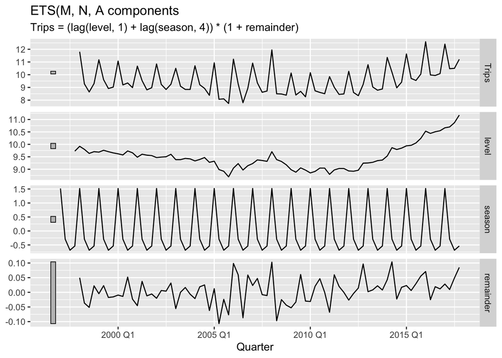

```r
components(fit) %>%
  autoplot() +
  labs(title = "ETS(M, N, A components")
```

Because this model has multiplicative errors, the innovation residuals are not equivalent to the regular residuals (i.e., the one-step training errors). The innovation residuals are given by $\hat{\epsilon_t}$ while the regular residuals are defined as $y_t - \hat{y}_{t|t-1}$. We can obtain both using the `augment()` function. They are plotted in Figure 8.11.

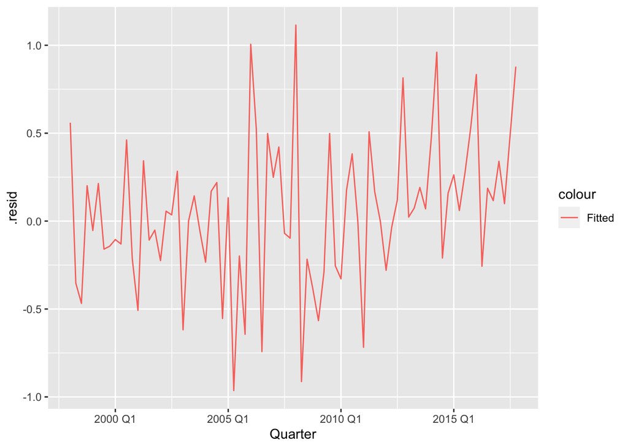

```r
augment(fit) %>%
  ggplot(aes(x = Quarter)) +
  geom_line(aes(y = .resid, colour = "Fitted"))
```

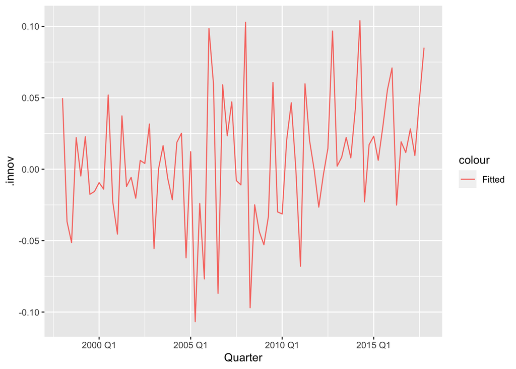

```r
augment(fit) %>%
  ggplot(aes(x = Quarter)) +
  geom_line(aes(y = .innov, colour = "Fitted"))
```

## 8.7 Forecasting methods with ETS

Point forecasts can be obtained from the models by iterating the equations for $t = T + 1,..., T + h$ and setting all $\epsilon_t = 0$ for $t \gt T$.

For example, for model ETS(M, A, N), $y_{T+1} = (\ell_t + b_T)(1 + \epsilon_{T+1})$. Therefore $\hat{y}_{T+1|T} = \ell_T + b_T$. Similarly,

$t_{T+2} = (\ell_{T+1} + b_{T + 1})(1 + \epsilon_{T + 2})$  
$= [(\ell_t + b_t)(1 + \alpha \epsilon_{T + 1}) + b_T + \beta(\ell_t + b_T) \epsilon_{T+1}](1 + \epsilon_{T+2})$

To obtain forecasts from an ETS model, we use the `forecast()` function from the `fable` package. The function will always return the means of the forecast distribution, even when they differ from these traditional point forecasts.

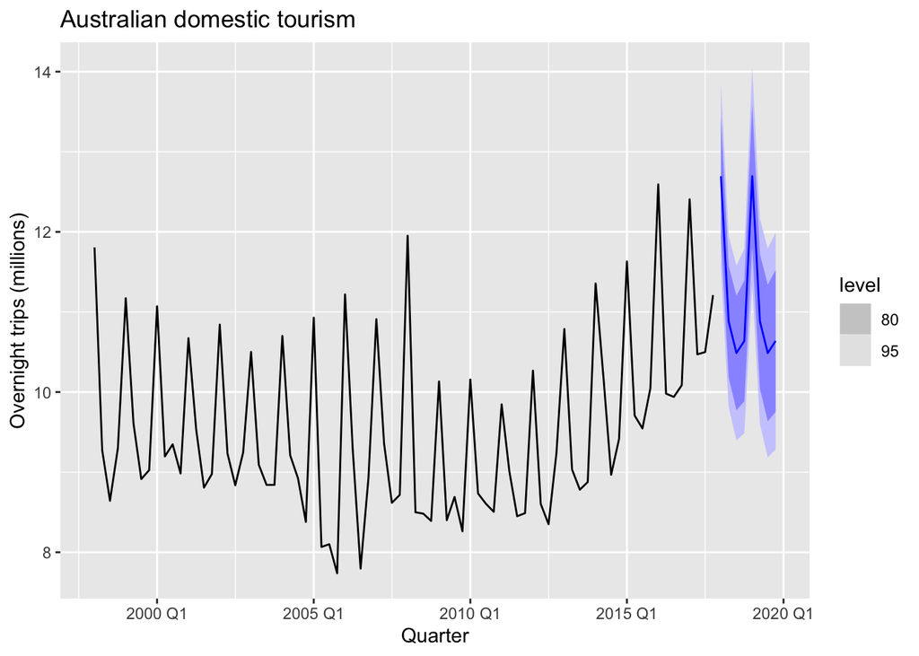

```r
fit %>%
  forecast(h = 8) %>%
  autoplot(aus_holidays) +
  labs(title = "Australian domestic tourism", y = "Overnight trips (millions)")
```

## Prediction intervals

A big advantage of the statistical models is that prediction intervals can also be generated — something that cannot be done using the point forecasting methods alone. The prediction intervals will differ between models with additive and multiplicative methods.

For most ETS models, a prediction interval can be written as

$\hat{y}_{T+h|T} \pm c \sigma_h$

where $c$ depends on the coverage probability, and $\sigma^2$ is the forecast variance. Values for $c$ were given in table 5.1. For ETS models, formulas for $\sigma_h^2$ can be complicated; the details are given in Chapter 6 of Hyndman et al. (2008). In Table 8.8 we give the formulas for the additive ETS models, which are the simplest.

Table 8.8: Forecast variance expressions for each additive state space model, where $\sigma^2$ is the residual variance, $m $is the seasonal period, and $k$ is the integer part of $(h-1) / m$ (i.e., the number of complete years in the forecast period prior to time $T + h)$.

| Model | Forecast variance: $\sigma_h^2$ |
| --- | --- |
| (A,N,N) | $\sigma^2_h = \sigma^2[1 + \alpha^2(h-1)]$ |
| (A, A, N) | $\sigma_h^2 = \sigma^2\Big[1 + (h-1)\big\{\alpha^2 + \alpha\beta h + \frac16\beta^2h(2h-1)\big\}\Big]$ |
| (A, $A_d$, N) | $\sigma_h^2 = \sigma^2\biggl[1 + \alpha^2(h-1) + \frac{\beta\phi h}{(1-\phi)^2} \left\{2\alpha(1-\phi) +\beta\phi\right\}$ |
| (A, N, A) | $\sigma_h^2 = \sigma^2[1 + \alpha^2](h-1) + \gamma k (2 \alpha + \gamma)$ |
| (A, A, A) | $\sigma_h^2 = \sigma^2 [1 + (h-1)] \left\{ \alpha^2 + \alpha\beta h + \frac{1}{6}\beta^2 h (2h-1) \right\} + \gamma k \left\{ 2\alpha + \gamma + \beta m(k+1) \right\}$ |

Conclusion of chapter 8. Wow!